# Il previsore ottimo

La previsione puntuale nell’ambito delle serie storiche mira a fornire un valore futuro di Y sulla base dei regressori $X_1,...,X_m$.

$$Y|X_1, ...,X_m$$

L’errore di previsione è definito come:

$$E = Y - P(X_1, ... , X_m)$$
cioè la differenza tra il vero valore e la sua previsione $P$ basata sui regressori quindi è una funzione misurabile delle esplicative $X_1, ..., X_m$

$E$ è l’errore di previsione se io sottoprevedo errore positivo se sopraprevedo errore negativo.

L’errore di per se non ci dicono quanto costa fare un errore per far questo interviene il concetto di funzione di perdita: La funzione di persita (loss funcion) $l(e)$ può essere di diversi tipi:

- *Quadratica* $l(e)=e^2$: penalizza gli errori “grandi” in maniera più che proporzionale rispetto a quelli “piccoli”. Si utilizza spesso perché è matematicamente comoda.

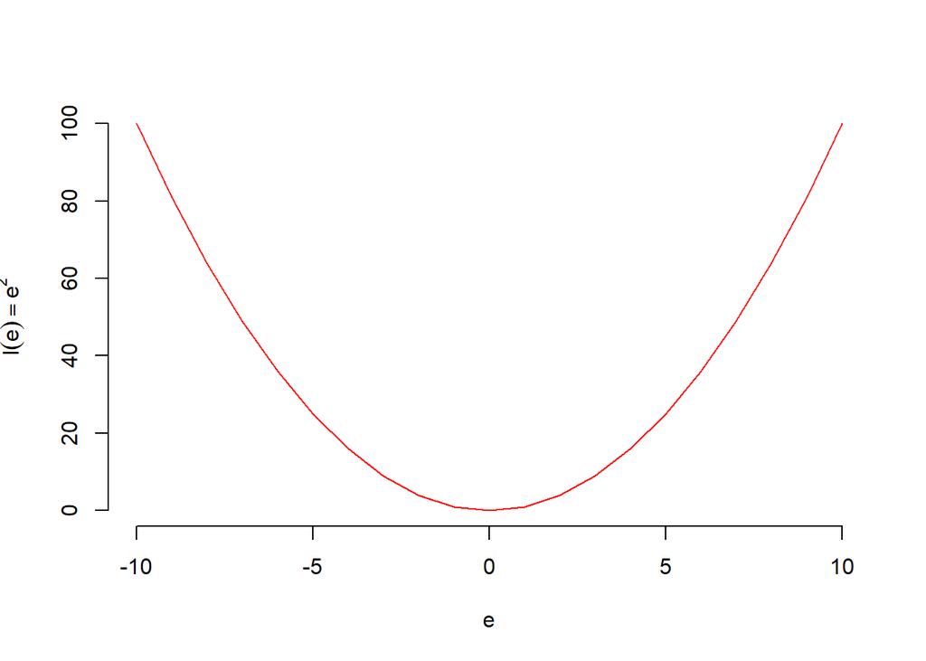

- *Assoluta* $l(e)=|e|$: penalizza meno gli errori “grandi”.

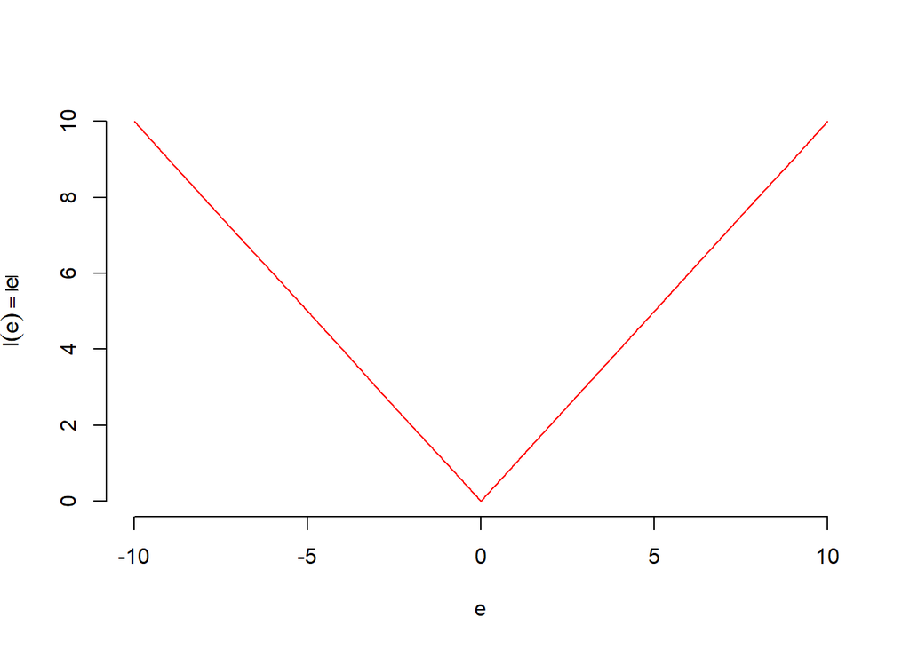

- *Asimmetrica*: nel caso in cui i costi di perdita siano diversi per errori in positivo piuttosto che in negativo, ades. nel caso in cui si produca troppo poco, si dovrà costruire una funzione di perdita che penalizzi in modo asimmetrico errori di sotto-previsione o di sovra-previsione.

Per esempio:
$$l(e) = \begin{cases} 19e, & \mbox{if } e>0 \\ -2e, & \mbox{if } e<0 \end{cases}$$

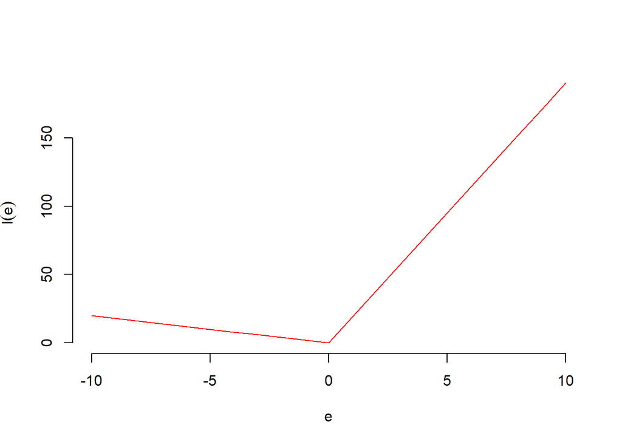

- Se ne potrebbero considerare anche altre, dipende dall’obiettivo che ci si pone.